# HHTS: transit ridership (2017, 2019, 2021) Analysis

#### Focusing on Active/Public Transit

To look at numbers more closely

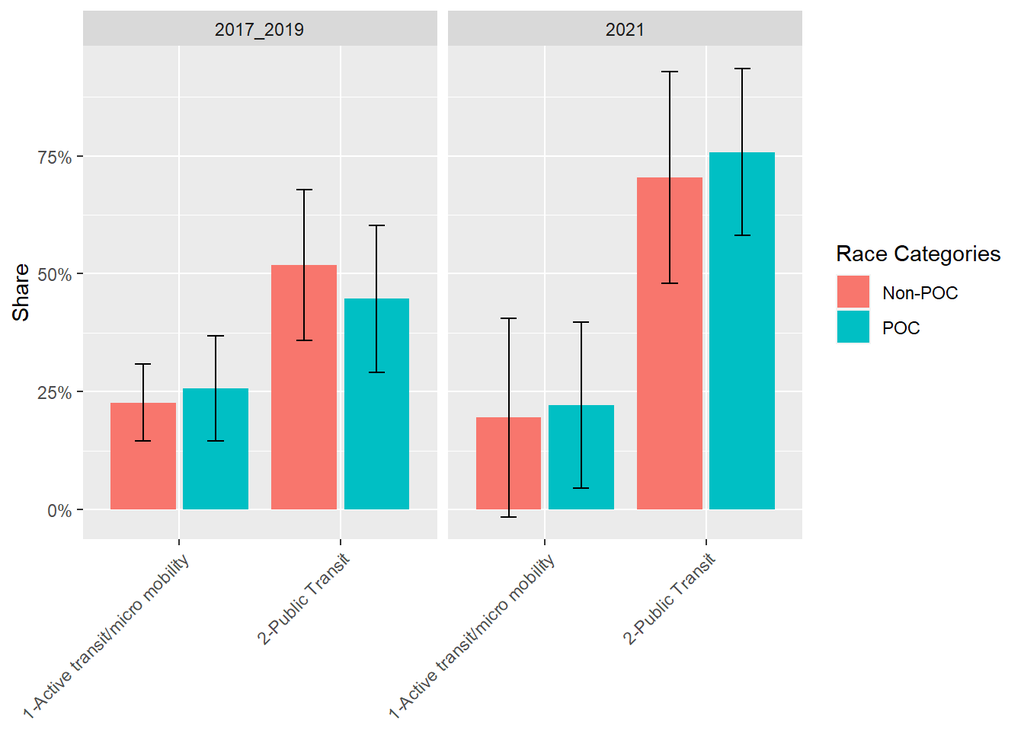

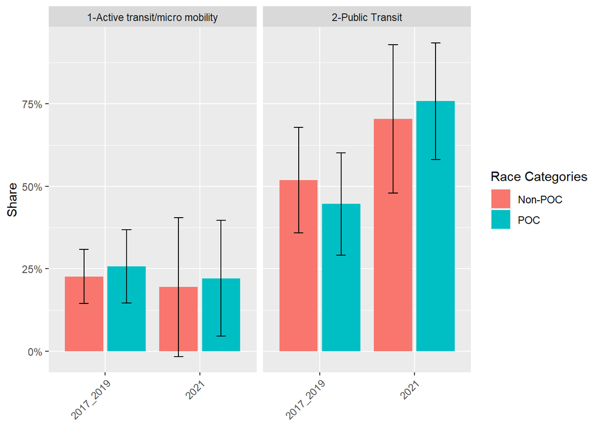

### Race - Asian POC/Non-Asian POC/White

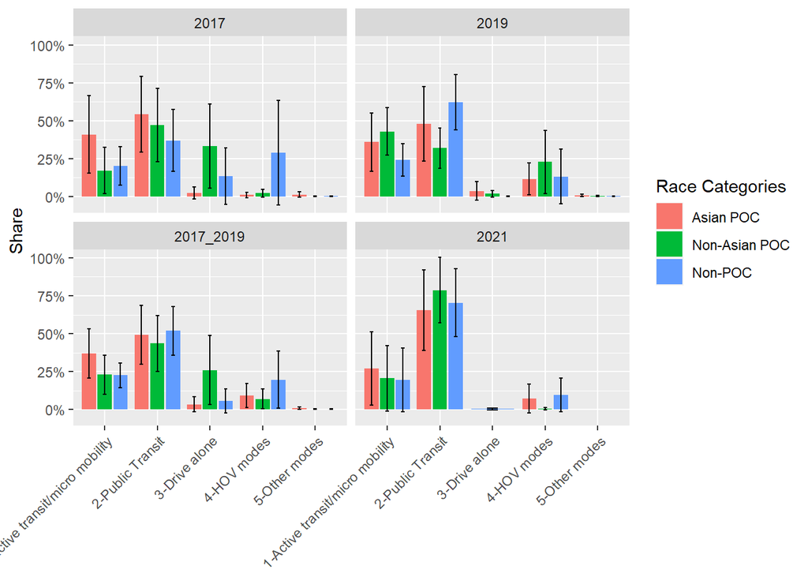

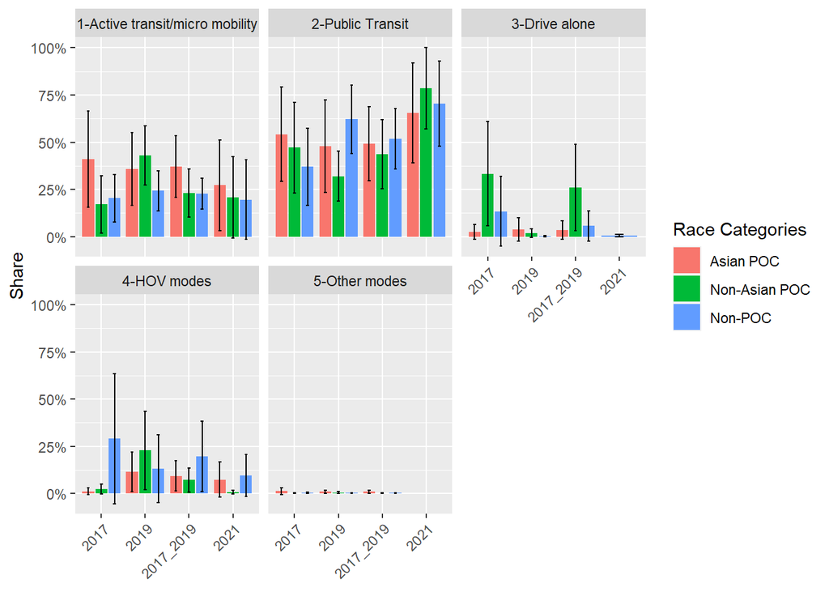

#### Focusing on Active/Public Transit

To look at numbers more closely

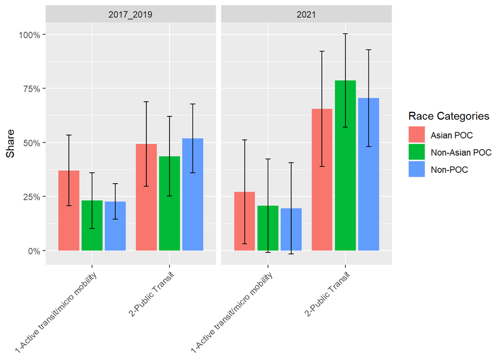

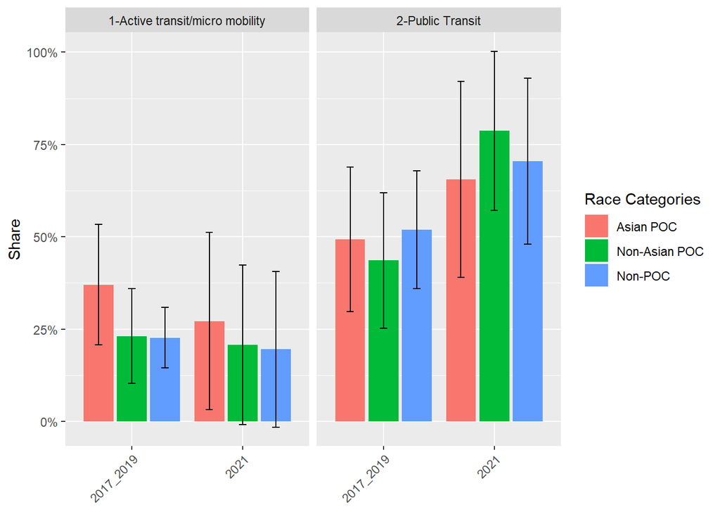

## Income

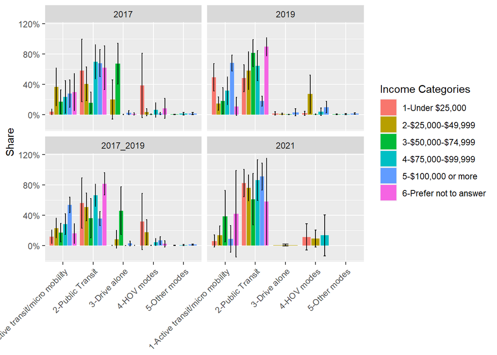

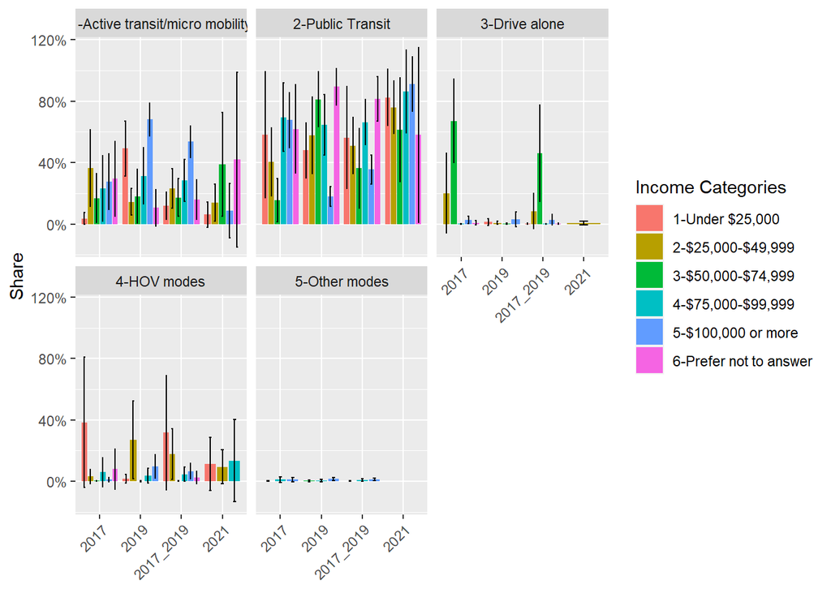

#### Focusing on Active/Public Transit

To look at numbers more closely

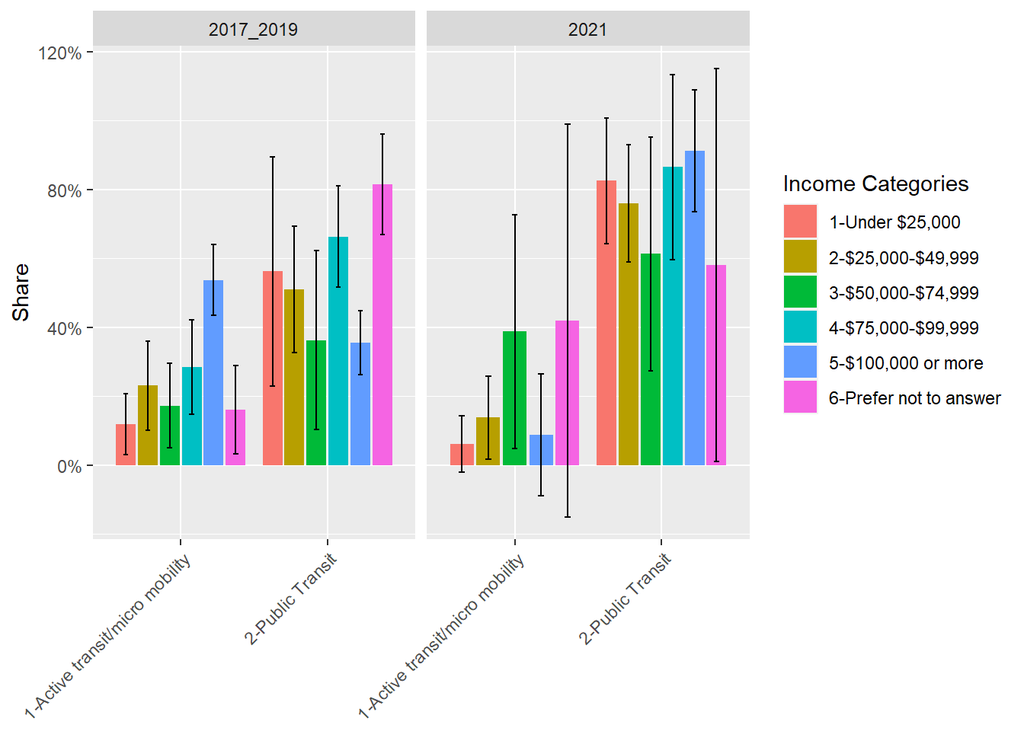

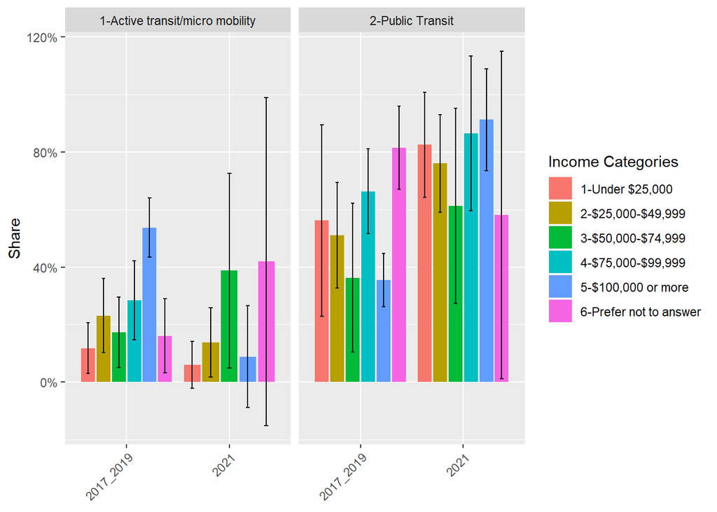

## Education

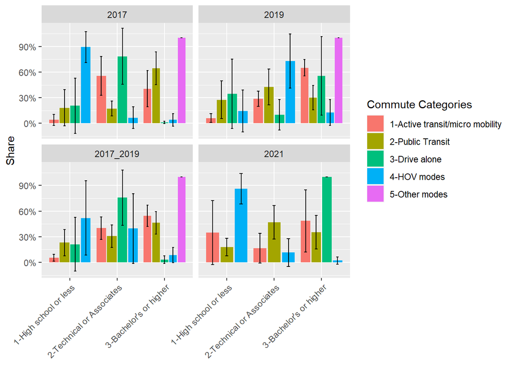

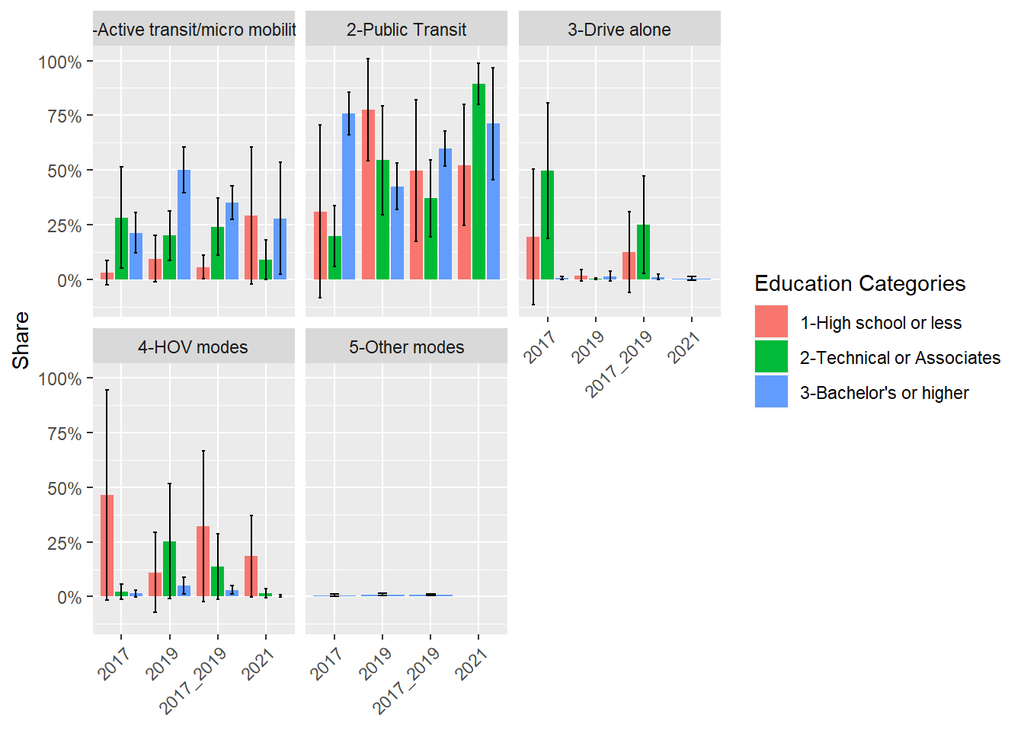

#### Focusing on Active/Public Transit

To look at numbers more closely

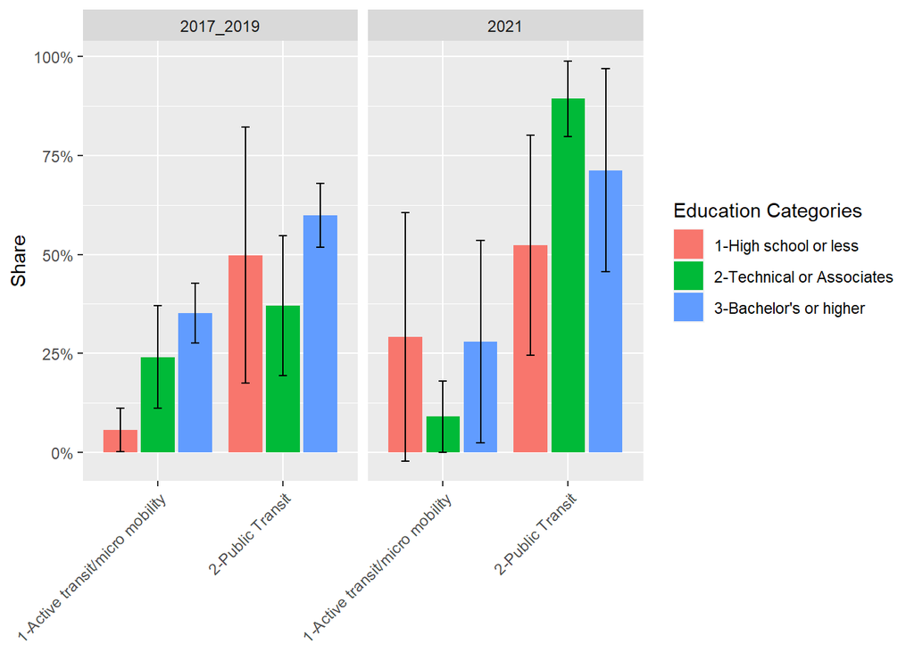

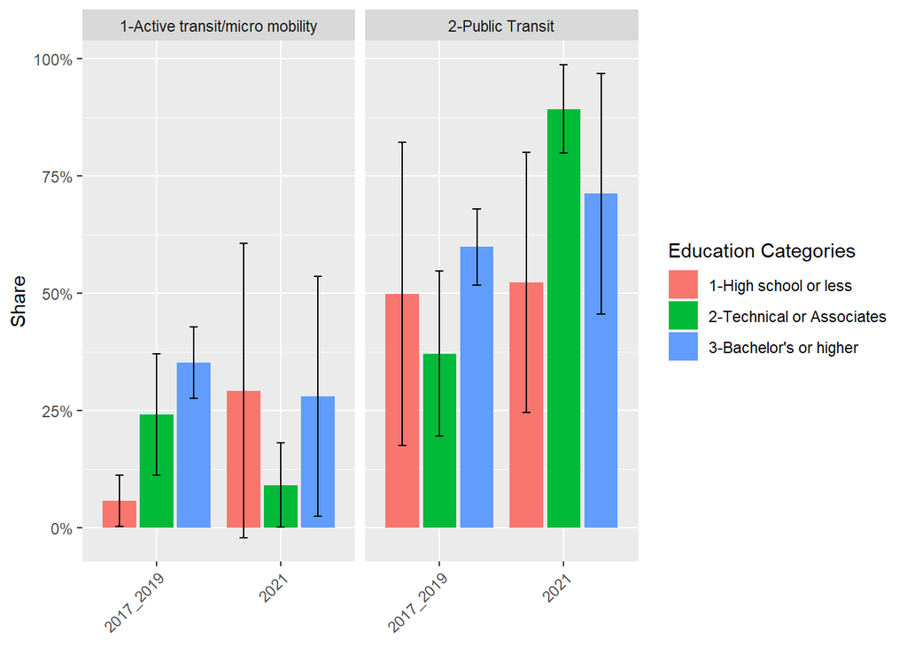

## Regional Growth Center

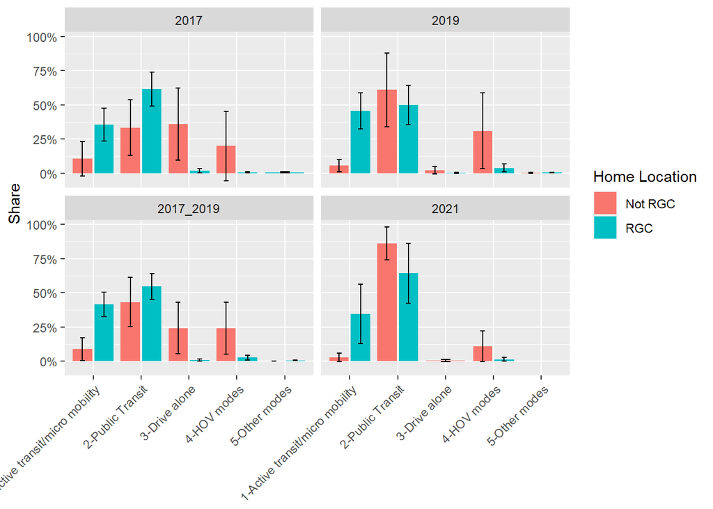

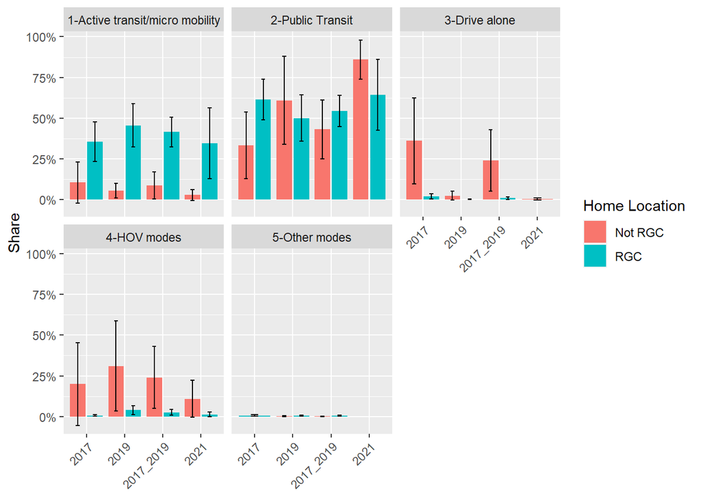

#### Focusing on Active/Public Transit

To look at numbers more closely

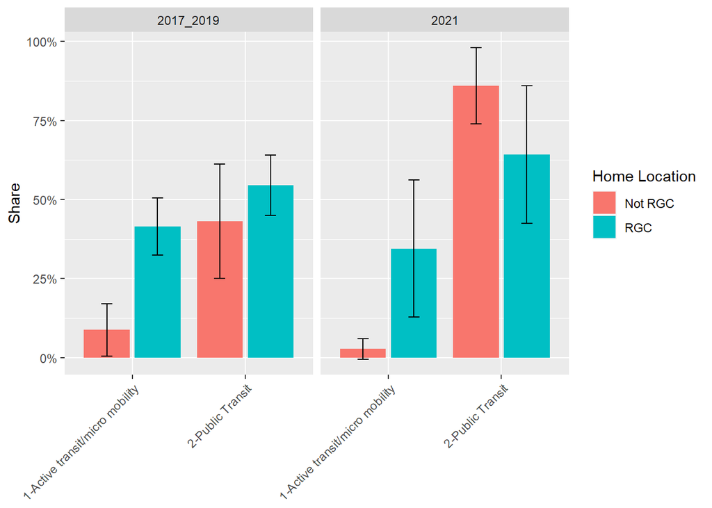

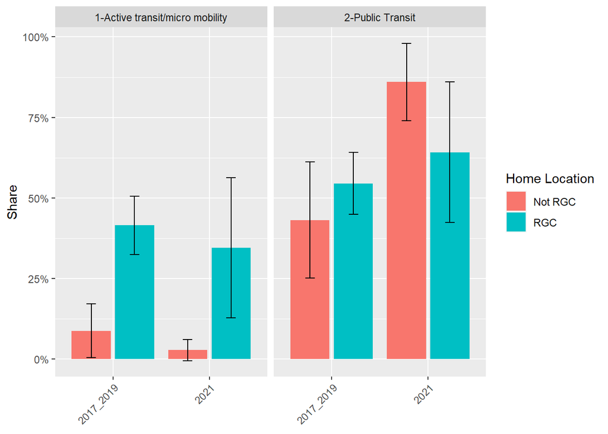

# Vehicle Ownership

There are different ways to quantify vehicle ownership

1. **hhsize/vehicle_count**: Household size
2. **numadults/vehicle_count**: Number of adults (18+)
3. **numworkers/vehicle_count**: Number of workers (number of household members with 1+ jobs)

Because we’re interested in commute modes, we will be focusing on the number of workers within a household.

## Number of vehicles per worker

The variables used to calculate this variable are:

1. Number of household vehicles

```
##
##                   2017 2017_2019 2019 2021
##   0 (no vehicles)  400       873  473  105
##   1 vehicle       1548      2972 1424  453
##   2 vehicles      1191      2184  993  565
##   3 vehicles       235       470  235  253
##   4 vehicles        66       139   73   81
##   5 vehicles        21        51   30   14
##   6 vehicles         3         8    5   10
##   7 vehicles         0         2    2    3
##   8+ vehicles        6         7    1    2
```

2. Number of workers

```
##
##     2017 2017_2019 2019 2021
##   1 1414      2643 1229  564
##   2 1856      3669 1813  735
##   3  160       316  156  121
##   4   37        61   24   55
##   5    3        17   14   10
##   6    0         0    0    1
```

### Race - all categories

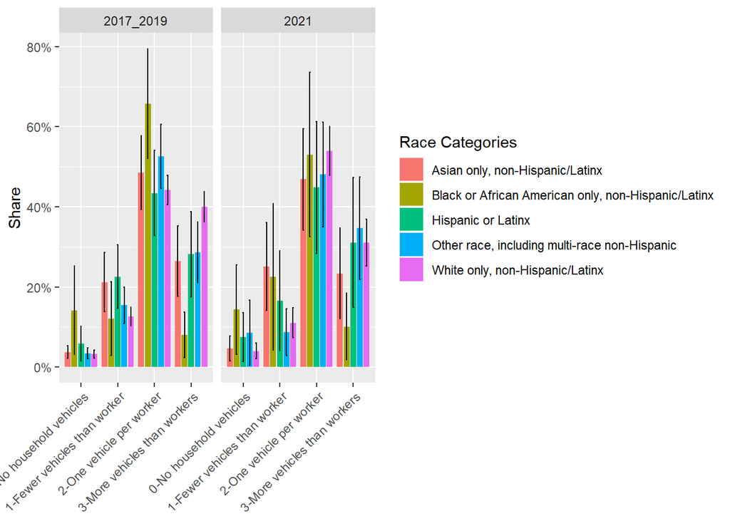

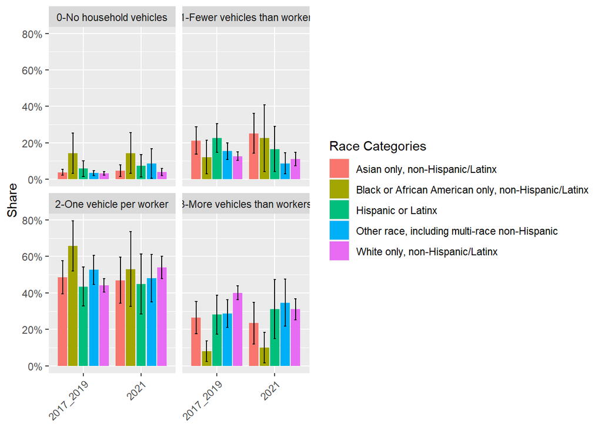

For households with more vehicles than workers, the difference between Black or African American and all other racial groups is larger in 2017/19 (especially compared to White only). In 2021, the MOEs overlap more with Black or African American, except for the White only individuals. In 2021 White only households decreased in this category and increased in the one vehicle per worker households.

### Race - POC/Non-POC

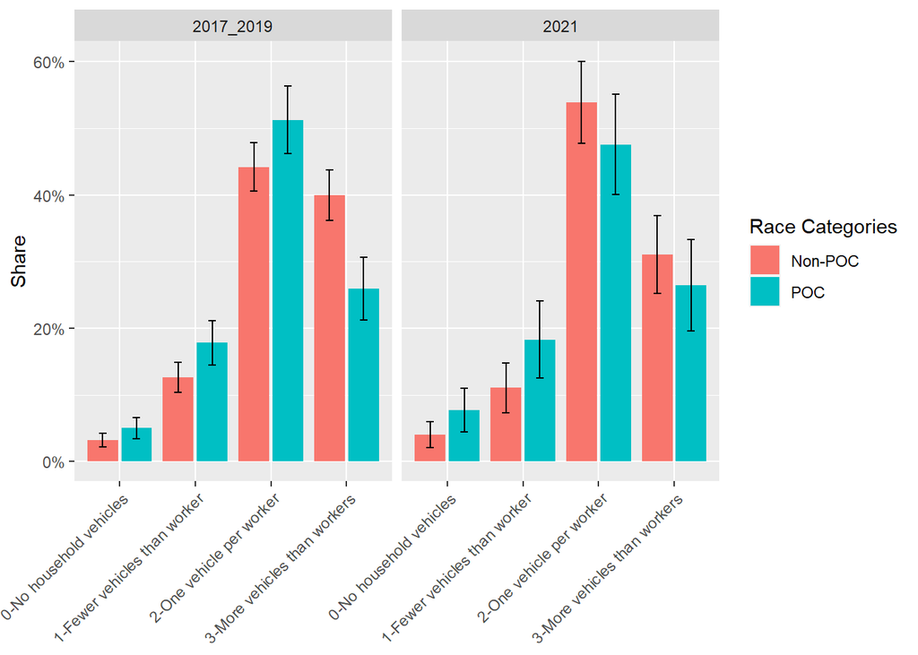

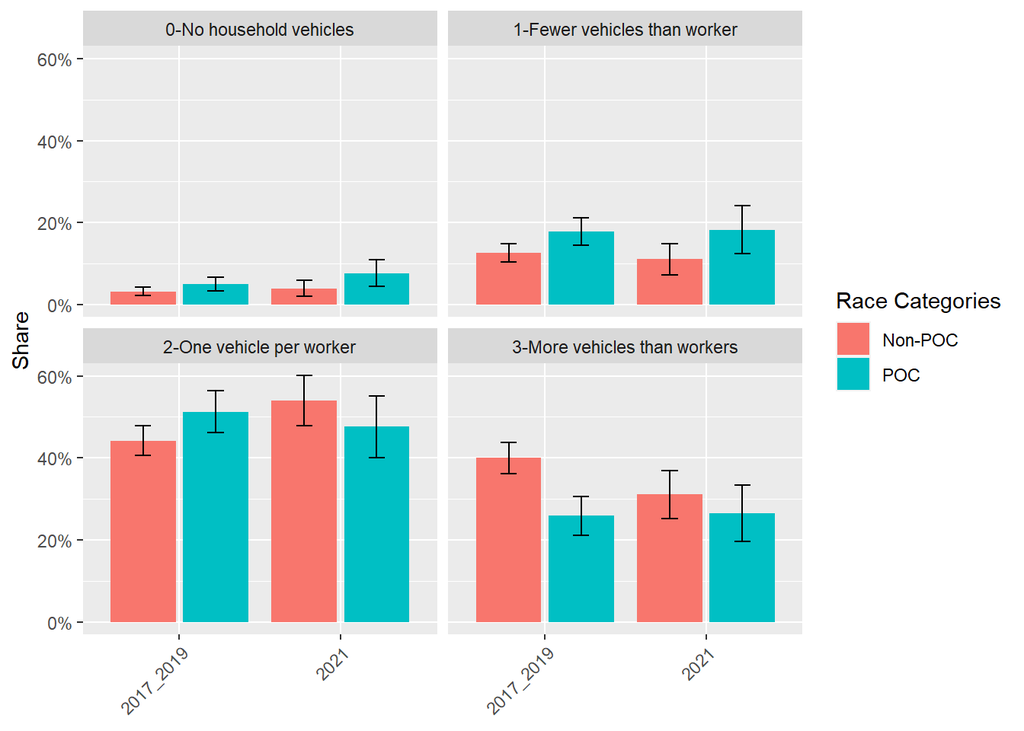

Non-POC households reported more vehicles than workers in 2017/19 compared to POC, but in 2021, the difference is smaller with overlapping MOEs. It’s difficult to determine any other differences over time because of MOEs. The trends and differences between groups seem relatively consistent over time. The trend for one-vehicle per worker households appears to shift between time periods, but the MOEs make it difficult to determine.

### Race - Asian POC/Non-Asian POC/White

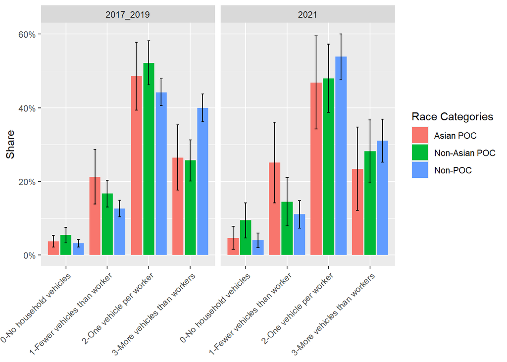

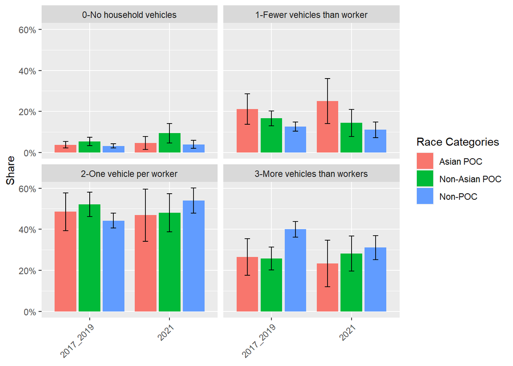

In 2021, there were more Asian POC households with fewer vehicles than workers compared to Non-POC, but the difference with Non-Asian POC is difficult to determine because of MOEs. In 2017/19 there were more Non-POC with more vehicles than workers than the other racial groups, but this difference decreased in 2021 - a difference that is looks mostly because of the decrease for Non-POC since the other groups remain similar over time.

## Income

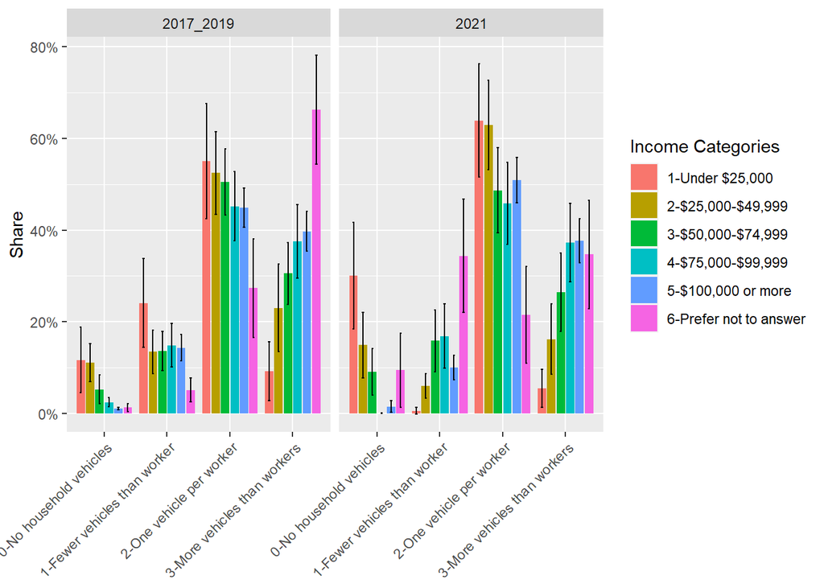

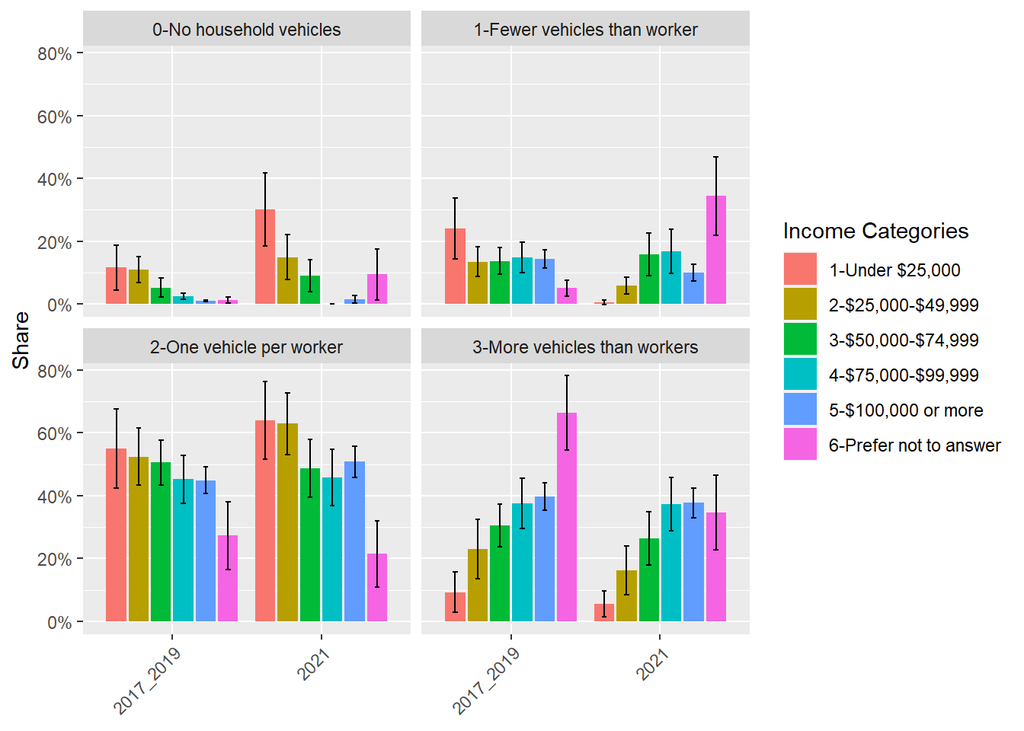

Zero-vehicle households tend to make less money than households with at least one vehicle, especially in 2021. The overlapping MOEs make it difficult to determine any other changes between years, but the trends seem similar. The number of the lowest income households with fewer vehicles per worker decreased over time, seemingly because the number of households without a vehicle increased.

## Education

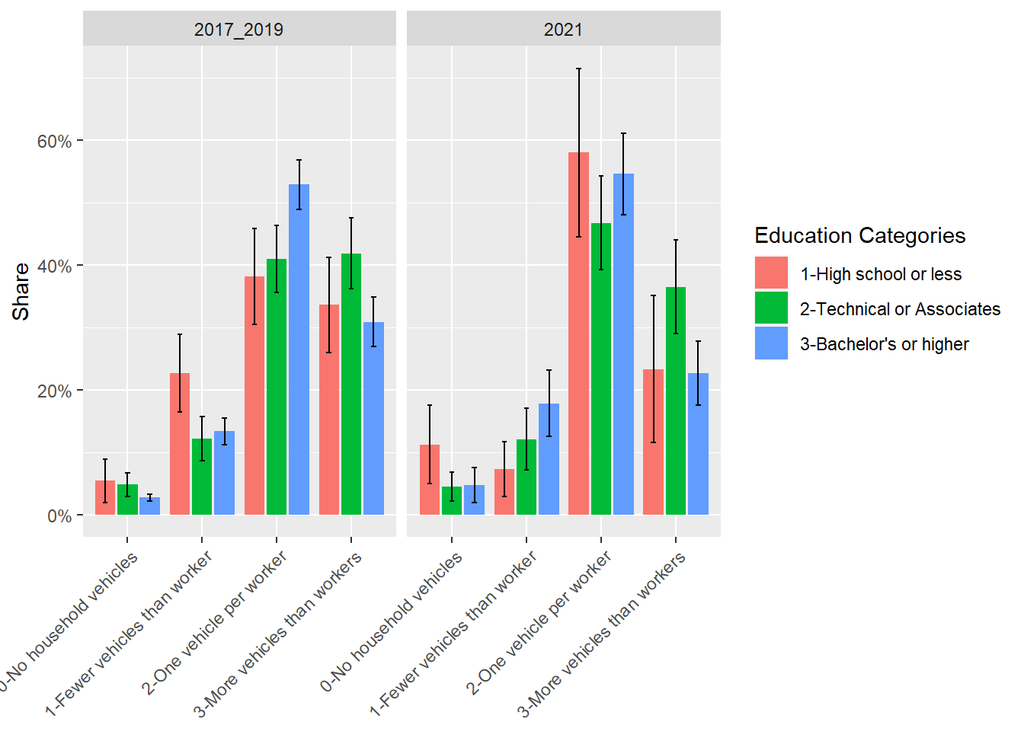

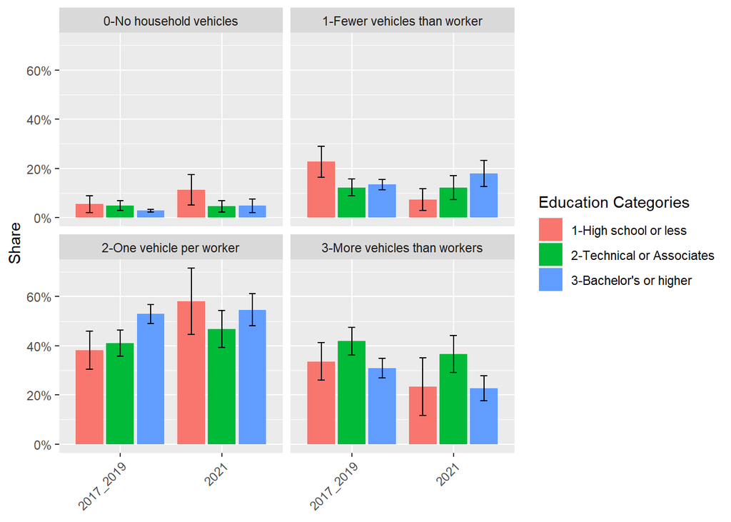

In 2021, the number of household vehicles per workers seemed to change for individuals with less education - increased in no vehicle households, decrease in fewer vehicle than worker households, and increase in one vehicle per worker households. There doesn’t seem to be too much of a difference between years for the other educational attainment levels. There may be a difference for individuals with bachelors degrees or higher in households with more vehicles than workers (decrease in 2021).

**Would it be better to create 2 groups instead of 3?**

```
##
##                             2017 2017_2019 2019 2021
##   1-High school or less      174       358  184  214
##   2-Technical or Associates  575      1142  567  478
##   3-Bachelor's or higher    2721      5206 2485  794
```

## Regional Growth Center

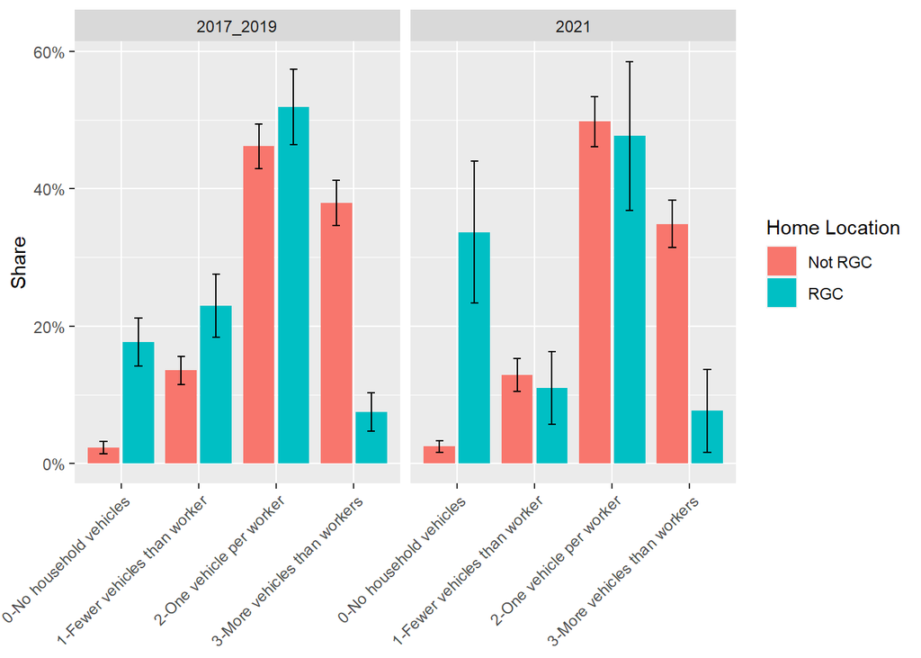

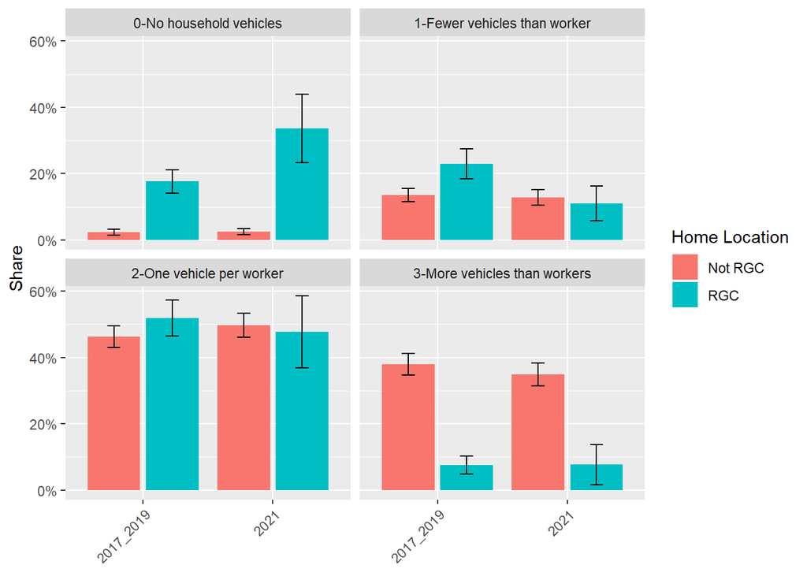

In 2021, for those living in RGCs, there was an increase in the zero vehicle households and a decrease in the fewer vehicles than workers households. The trends for those living outside of RGCs were similar between years.

## Commute Mode

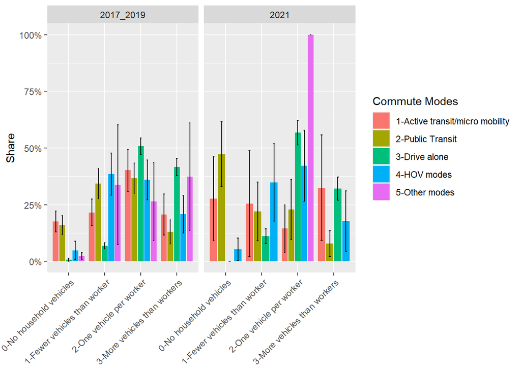

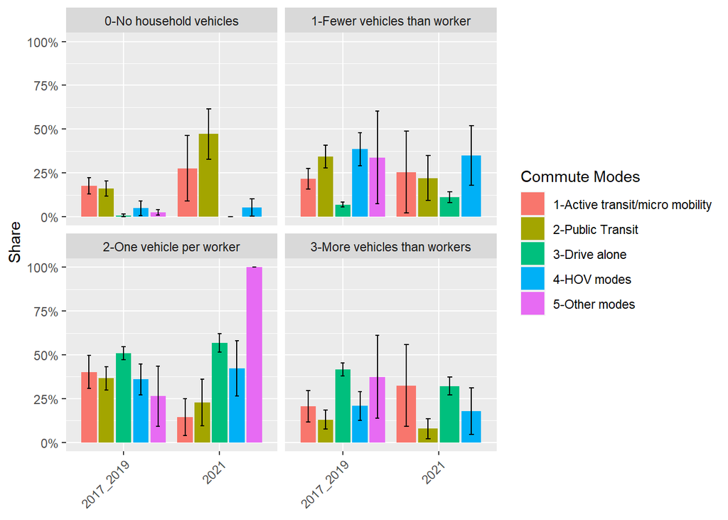

# Additional Research into Vehicle Ownership and Location

## Changes over time

To test if the number of zero-vehicle households in RGCs increased in 2021?

```
## [1] 0.3512017
```

As a basic test, there is no overlap in the 90 percent confidence intervals of the two estimates (2017/19 and 2021), so we can conclude that the values are different and that there was a change over time.  
This difference is confirmed with the z-score, 9.6320678^{4}

To test if the number of fewer vehicles than workers households decreased in 2021?

Following a similar process as before, there is no overlap between the two survey years indicating that there was a change over time.  
This difference is confirmed with the z-score, 3.532674^{4}

## External data sources for location

# END OF WORK FOR NOW——

# Analysis

## Transit and Household Auto Ownership

#### By Race

##### Simplified Vehicle Numbers

Back to top of the page